# STA6235_Final_Exam

Connor Baugh

2022-05-04

## Problem 1: Table of descriptive statistics by hypertension status

```r
library(readr)
library(vtable)
library(gmodels)
library(xtable)
library(tidyverse)
```

```r
library(patchwork)
library(ggcorrplot)
library(regclass)
JHS_final <- read_csv("JHS_final.csv")
df <- JHS_final[, c(50,10,16,13,64,22,48)]
df$HTN <- factor(df$HTN, levels = c("No", "Yes"), labels = c("Normotensive", "Hypertensive"))
labs <- c("A1C Percentage", "Age", "Alcohol Use", "Sex", "Total Cholesterol", "Waist Circumference")
sumtable(df, group = "HTN", labels = labs)
```

Summary Statistics

| HTN Variable | Normotensive N | Normotensive Mean | Normotensive SD | Hypertensive N | Hypertensive Mean | Hypertensive SD |
| --- | --- | --- | --- | --- | --- | --- |
| A1C Percentage | 1108 | 5.578 | 0.89 | 154 | 5.891 | 1.026 |
| Age | 1143 | 48.712 | 11.242 | 157 | 56.726 | 10.361 |
| Alcohol Use | 1138 |  |  | 157 |  |  |
| … No | 501 | 44% |  | 82 | 52.2% |  |
| … Yes | 637 | 56% |  | 75 | 47.8% |  |
| Sex | 1143 |  |  | 157 |  |  |
| … Female | 678 | 59.3% |  | 74 | 47.1% |  |
| … Male | 465 | 40.7% |  | 83 | 52.9% |  |
| Total Cholesterol | 1091 | 196.881 | 38.559 | 150 | 210.66 | 44.665 |
| Waist Circumference | 1140 | 96.594 | 15.327 | 157 | 101.408 | 16.006 |

## Problem 2: Model HbA1c as a function of the other variables

```r
model <- lm(HbA1c ~ age + alc + HTN + sex + totchol + waist, data = df)
coef(model)
```

```
##     (Intercept)             age          alcYes HTNHypertensive         sexMale
##    3.419182e+00    1.653558e-02   -2.028975e-02    1.430036e-01    1.540225e-02
##         totchol           waist
##    5.309967e-05    1.377326e-02
```

### 2a: State the resulting regression model

The resulting regression model as given by the estimated coefficients of the variables above is stated below as:

$\hat{A1C Percentage} = 3.4192 + 0.0165(Age) - 0.0203(Alcohol Use) + 0.1430(HTN) + 0.0154(Sex) + 0.0001(Total Cholesterol) + 0.0138(Waist Circumference)$,

where $\hat{A1C Percentage}$ is a patient’s estimated Hemoglobin HbA1c percentage level given the predictors’ values and estimated coefficients, ‘Alcohol Use’ is equal to 0 if the patient has not drunk in the past 12 months or 1 otherwise, ‘HTN’ is equal to 0 if the patient’s blood pressure is normotensive or 1 otherwise, and ‘Sex’ is equal to 0 if the patient is a female or 1 if they are a male.

### 2b: Table of predictors and their coefficients, confidence intervals, and p-values

```r
mat <- ci(model, confidence = 0.95)
mat <- data.frame(mat)
addpar <- function(x, y, z){paste(x," ","(",y,";",z,")", sep = "")}
mat$ci <- addpar(round(mat$Estimate, digits = 4), round(mat$CI.lower, digits = 4), round(mat$CI.upper, digits = 4))
summary(model)$coefficients[,4]
```

```
##     (Intercept)             age          alcYes HTNHypertensive         sexMale
##    3.428141e-53    2.282267e-13    6.804822e-01    5.851634e-02    7.529014e-01
##         totchol           waist
##    9.323435e-01    1.972808e-18
```

```r
mat$pvalue <- round(summary(model)$coefficients[,4], digits = 4)
coeff_tbl <- data.frame("pred" = c("Age", "Alcohol use (yes vs. no)", "Hypertension (yes vs. no)", "Sex (male vs. female)", "Total cholesterol", "Waist circumference"), "beta" = mat$ci[2:7], "pvalue" = mat$pvalue[2:7])
coeff_tbl %>% kbl(col.names = c("$Predictors$", "$\\hat{\\beta}$ $(95\\%$ $CI)$", "$p-value$")) %>% kable_classic(full_width = F)
```

| $Predictors$ | $\hat{\beta}$ $(95\%$ $CI)$ | $p-value$ |
| --- | --- | --- |
| Age | 0.0165 (0.0122;0.0209) | 0.0000 |
| Alcohol use (yes vs. no) | -0.0203 (-0.1169;0.0764) | 0.6805 |
| Hypertension (yes vs. no) | 0.143 (-0.0052;0.2912) | 0.0585 |
| Sex (male vs. female) | 0.0154 (-0.0806;0.1114) | 0.7529 |
| Total cholesterol | 1e-04 (-0.0012;0.0013) | 0.9323 |
| Waist circumference | 0.0138 (0.0107;0.0168) | 0.0000 |

### 2c: State significant predictors of A1c

From the table of predictors we created (and the summary output of the predictor p-values) above, we can see that only the variables ‘Age’ and ‘Waist circumference’ are statistically significant predictors of A1c at the 95% confidence level, with p-values of 2.282267e-13 and 1.972808e-18, respectively. Additionally, the intercept is also statistically significant at the 95% confidence level with a p-value of 3.428141e-53, however it was not included in the table above. Lastly, it is worth noting that the ‘Hypertension’ variable is very close to being significant at the 95% confidence level, with a p-value of 0.0585.

### 2d: Brief intereptation of each predictor

Given the constructed regression model and the coefficient table created in the previous sections, we can interpret each predictor (Intercept, Age, Alcohol use, Hypertension, Sex, Total cholesterol, and Waist circumference, respectively) as such:

Negating all other predictors, we expect the average A1c percentage level of a female patient who’s blood pressure is normotensive and has not drunk in the past 12 months to be 3.4192%. For each unit increase in a patient’s age, the patient’s A1c percentage level is expected to increase by 0.0165%, holding all other predictors constant. On average, patients who have drunk alcohol in the past 12 months are expected to have A1c percentage levels that are 0.0203% lower than patients who have not drunk alcohol in the past 12 months, holding all other predictors constant. On average, patients who have hypertension are expected to have A1c percentage levels that are 0.143% higher than patients who do not have hypertension, holding all other predictors constant. On average, male patients are expected to have A1c percentage levels that are 0.0154% higher than female patients, holding all other factors constant. For each unit increase in total cholesterol, a patient’s A1c percentage level is expected to increase by 0.0001%, holding all other predictors constant. Lastly, for each centimeter increase in a patient’s waist circumference, the patient’s A1c percentage level is expected to increase by 0.0138%, holding all other predictors constant.

## Problem 3: Model HbA1c with all two-way interactions involving hypertension status

```r
model.inter <- lm(HbA1c ~ age + alc + HTN + sex + totchol + waist + age:HTN + alc:HTN + sex:HTN + totchol:HTN + waist:HTN, data = df)
coef(model.inter)
```

```
##             (Intercept)                     age                  alcYes
##            3.4500980486            0.0170441958           -0.0054124221
##         HTNHypertensive                 sexMale                 totchol
##            0.2042828670            0.0597368102           -0.0005564589
##                   waist     age:HTNHypertensive  alcYes:HTNHypertensive
##            0.0141663266           -0.0064923345           -0.0053055513
## HTNHypertensive:sexMale HTNHypertensive:totchol   HTNHypertensive:waist
##           -0.3621649716            0.0037427095           -0.0028281410
```

### 3a: State the resulting regression model

The resulting regression model as given by the estimated coefficients of the variables above is stated below as:

$\hat{A1C Percentage} = 3.4501 + 0.0170(Age) - 0.0054(Alcohol Use) + 0.2043(HTN) + 0.0597(Sex) - 0.0006(Total Cholesterol) + 0.0142(Waist Circumference) - 0.0065(Age:HTN) - 0.0053(Alcohol Use:HTN) - 0.3621(Sex:HTN) + 0.0037(Total Cholesterol:HTN) - 0.0028(Waist Circumference:HTN)$,

where $\hat{A1C Percentage}$ is a patient’s estimated Hemoglobin HbA1c percentage level given the predictors’ values and estimated coefficients, ‘Alcohol Use’ is equal to 0 if the patient has not drunk in the past 12 months or 1 otherwise, ‘HTN’ is equal to 0 if the patient’s blood pressure is normotensive or 1 otherwise, and ‘Sex’ is equal to 0 if the patient is a female or 1 if they are a male.

### 3b: Show that all interaction terms cannot be dropped simultaneously using a single hypothesis test

To test if we can drop all of the interaction terms simultaneously, we must run a partial F-test. Before we run the test however, we must define our hypotheses. In this case, the null hypothesis states that the original (reduced) model and the model with the addition of all two-way interactions involving hypertension status (full) do not differ significantly and the alternative hypothesis states that the full model is significantly better at predicting the outcome than the reduced model. More formally, the 2 hypotheses state that all the coefficients removed from the full model are zero and at least 1 of the coefficients removed from the model is not zero, respectively. The 2 hypotheses can be displayed in the format below:

$H_0$: $\beta_{Age:HTN} = \beta_{Alcohol Use:HTN} = \beta_{Sex:HTN} = \beta_{Total Cholesterol:HTN} = \beta_{Waist Circumference:HTN} = 0$

$H_1$: At least one $\neq 0$

The partial F-test between the original model and the model with the addition of all two-way interactions involving hypertension status is run below in R:

```r
anova(model, model.inter)
```

```
## Analysis of Variance Table
##
## Model 1: HbA1c ~ age + alc + HTN + sex + totchol + waist
## Model 2: HbA1c ~ age + alc + HTN + sex + totchol + waist + age:HTN + alc:HTN +
##     sex:HTN + totchol:HTN + waist:HTN
##   Res.Df    RSS Df Sum of Sq      F  Pr(>F)
## 1   1210 829.91
## 2   1205 822.06  5    7.8561 2.3031 0.04273 *
## ---
## Signif. codes:  0 '***' 0.001 '**' 0.01 '*' 0.05 '.' 0.1 ' ' 1
```

Given the results of the ANOVA partial F-test, we can reject the null hypothesis as there is sufficient evidence that the full model is significantly better at predicting the outcome than the reduced model at the 95% confidence level. Therefore, we cannot drop all of the interaction terms at the same time because at least one of the interactions is statistically significant at the 95% confidence level.

### 3c: Determine which interaction terms can be dropped using multiple hypothesis tests

To determine which interaction terms can be dropped, we can utilize the summary( ) function in R. The summary( ) function automatically runs individual t-tests for each predictor variable in the model and presents the associated p-values in the results. We are able to access the p-values for each of the predictors using the summary( ) function as shown in R below:

```r
summary(model.inter)$coefficients[,4]
```

```
##             (Intercept)                     age                  alcYes
##            2.530136e-49            7.551030e-13            9.174557e-01
##         HTNHypertensive                 sexMale                 totchol
##            7.922923e-01            2.504012e-01            4.122865e-01
##                   waist     age:HTNHypertensive  alcYes:HTNHypertensive
##            3.859967e-17            3.910381e-01            9.734536e-01
## HTNHypertensive:sexMale HTNHypertensive:totchol   HTNHypertensive:waist
##            2.053260e-02            3.174042e-02            5.467686e-01
```

Given the p-values of the predictors above, we can determine that only the interaction terms between sex and hypertension status and total cholesterol and hypertension status are statistically significant predictors of A1c percentage at the 95% confidence level or higher. Therefore, all other interaction terms (Age:HTN, Alcohol Use:HTN, and Waist Circumference:HTN) can be dropped from the model.

## Problem 4: Model HbA1c with the significant two-way interactions involving hypertension status

```r
model.sig <- lm(HbA1c ~ age + alc + HTN + sex + totchol + waist + sex:HTN + totchol:HTN, data = df)
coef(model.sig)
```

```
##             (Intercept)                     age                  alcYes
##            3.4915262132            0.0164911429           -0.0056904835
##         HTNHypertensive                 sexMale                 totchol
##           -0.3873615243            0.0604681682           -0.0005119098
##                   waist HTNHypertensive:sexMale HTNHypertensive:totchol
##            0.0139236331           -0.3539620864            0.0034223041
```

### 4a: State the resulting regression model

The resulting regression model as given by the estimated coefficients of the variables above is stated below as:

$\hat{A1C Percentage} = 3.4915 + 0.0165(Age) - 0.0057(Alcohol Use) - 0.3874(HTN) + 0.0605(Sex) - 0.0005(Total Cholesterol) + 0.0139(Waist Circumference) - 0.3540(Sex:HTN) + 0.0034(Total Cholesterol:HTN)$,

where $\hat{A1C Percentage}$ is a patient’s estimated Hemoglobin HbA1c percentage level given the predictors’ values and estimated coefficients, ‘Alcohol Use’ is equal to 0 if the patient has not drunk in the past 12 months or 1 otherwise, ‘HTN’ is equal to 0 if the patient’s blood pressure is normotensive or 1 otherwise, and ‘Sex’ is equal to 0 if the patient is a female or 1 if they are a male.

### 4b: Create visualizations to help explain the interaction terms

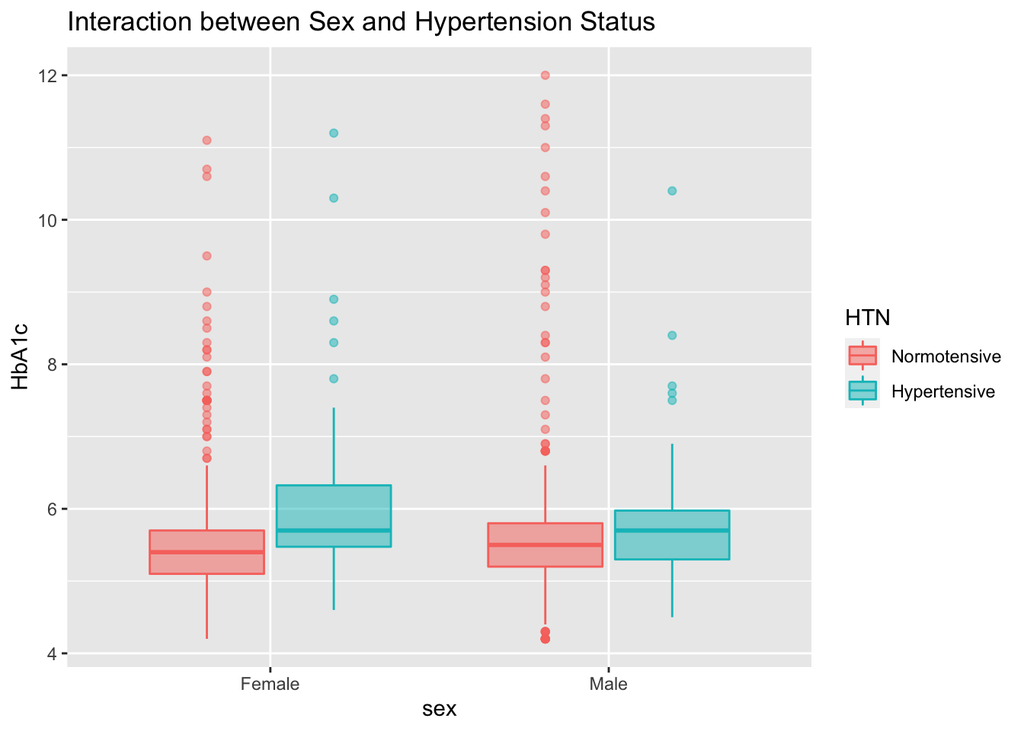

```r
ggplot(data = df, aes(x = sex, y = HbA1c, fill = HTN, colour = HTN))+geom_boxplot(alpha = 0.5)+ggtitle("Interaction between Sex and Hypertension Status")
```

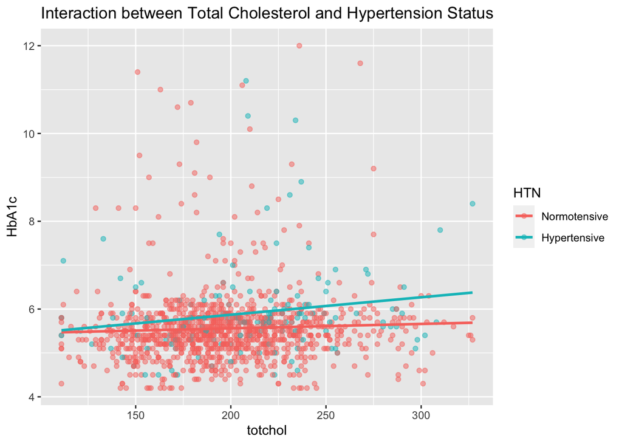

```r
ggplot(data = df, aes(x = totchol, y = HbA1c, group = HTN, colour = HTN))+geom_point(alpha = 0.5)+geom_smooth(method = 'lm', se = FALSE)+ggtitle("Interaction between Total Cholesterol and Hypertension Status")
```

### 4c: Write a sumary paragraph explaining the interaction terms given the graphs

Based on the graphs visualizing the two interaction terms above, we can see that the individual effects of a patient’s sex and total cholesterol on their expected A1c percentage level differ significantly depending on their hypertension status. Specifically, given the visualization of the interaction between sex and hypertension status, the expected difference in A1c percentage levels between male and female patients changes depending on their hypertension status, which can be observed by the change in median, inter-quartile range (IQR), and minimum and maximum observations of patients of different sexes depending on their hypertension status. Perhaps more intuitively, we can see the difference in the effect of a patient’s total cholesterol on their A1c percentage level depending on hypertension status as shown in the visualization of the interaction between total cholesterol and hypertension status. The graph of the interaction makes it very clear that the percent increase in A1c for each unit increase in total cholesterol strongly depends on a patient’s hypertension status, which can be intuitively understood by the change in the slope of the graph.

## Problem 5

### 5a: Create a flag variable for outliers to determine the number of potential outliers

To create our flag variable for outliers, we first calculate the Cooks Distance of each observation in the model. After we calculate Cooks Distance, we use the rule of thumb of 4 times the average Cooks Distance as our outlier threshold. Once the outliers are determined, we use the table( ) function to count the number of potential outliers found.

```r
cooksd <- cooks.distance(model.sig)
table(ifelse(cooksd>4*mean(cooksd, na.rm=T), "Outlier", "NA"))
```

```
##
##      NA Outlier
##    1166      51
```

Based on the outlier table above, we find that there are 51 potential outliers in the dataset.

### 5b: Determine the number of potential outliers using the graph for Cooks Distance

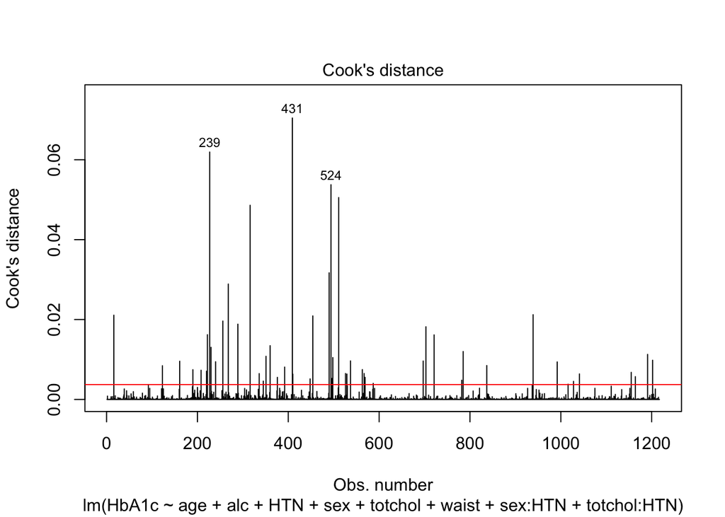

```r
plot(model.sig, which = 4)
abline(h=4*mean(cooksd), col = "red")
```

Based on the graph for Cook’s Distance, we find that 51 potential influence/leverage points exist in the dataset.

### 5c: Conduct a sensitivity analysis and exclude the outliers

```r
outliers <- (cooksd>4*mean(cooksd, na.rm=T))
cooksd[outliers]
```

```
##          16         131         169         200         219         231
## 0.021090189 0.008434347 0.009568939 0.007453580 0.007310231 0.007076232
##         233         239         243         254         271         283
## 0.016202615 0.061932179 0.013045194 0.009436773 0.019620814 0.028886204
##         306         334         354         364         370         379
## 0.018837922 0.048602400 0.006464976 0.004593516 0.010802648 0.013464493
##         396         414         431         432         475         481
## 0.005527744 0.008104772 0.070447286 0.006345241 0.005151237 0.020912377
##         520         524         527         530         546         561
## 0.031701467 0.053745101 0.005267672 0.010480619 0.050534757 0.006487530
##         564         572         606         610         613         631
## 0.006363345 0.009639822 0.007471760 0.006498472 0.005535141 0.004014900
##         746         752         770         835         838         894
## 0.009616480 0.018196018 0.016158195 0.004818653 0.011998735 0.008486042
##        1006        1063        1088        1100        1114        1233
## 0.021215895 0.009389511 0.003815101 0.004524852 0.006388338 0.006779841
##        1242        1270        1284
## 0.005707026 0.011272990 0.009810554
```

```r
out <- c(16, 131, 169, 200, 219, 231, 233, 239, 243, 254, 271, 283, 306, 334, 354, 364, 370, 379, 396, 414, 431, 432, 475, 481, 520, 524, 527, 530, 546, 561, 564, 572, 606, 610, 613, 631, 746, 752, 770, 835, 838, 894, 1006, 1063, 1088, 1100, 1114, 1233, 1242, 1270, 1284)
new.df <- df %>% filter(!row_number() %in% out)
model.new <- lm(HbA1c ~ age + alc + HTN + sex + totchol + waist + sex:HTN + totchol:HTN, data = new.df)
coef(model.new)
```

```
##             (Intercept)                     age                  alcYes
##            3.8270372504            0.0121899514           -0.0179301654
##         HTNHypertensive                 sexMale                 totchol
##           -0.3767947704           -0.0113850423            0.0001212417
##                   waist HTNHypertensive:sexMale HTNHypertensive:totchol
##            0.0107668026           -0.1166021523            0.0024684821
```

#### 5ci: State the resulting regression model

The resulting regression model as given by the estimated coefficients of the variables above is stated below as:

$\hat{A1C Percentage} = 3.8270 + 0.0122(Age) - 0.0179(Alcohol Use) - 0.3768(HTN) - 0.0114(Sex) + 0.0001(Total Cholesterol) + 0.0108(Waist Circumference) - 0.1166(Sex:HTN) + 0.0025(Total Cholesterol:HTN)$,

where $\hat{A1C Percentage}$ is a patient’s estimated Hemoglobin HbA1c percentage level given the predictors’ values and estimated coefficients, ‘Alcohol Use’ is equal to 0 if the patient has not drunk in the past 12 months or 1 otherwise, ‘HTN’ is equal to 0 if the patient’s blood pressure is normotensive or 1 otherwise, and ‘Sex’ is equal to 0 if the patient is a female or 1 if they are a male.

#### 5cii: Table of both models’ predictors, coefficients, confidence intervals, and p-values

```r
mat.df <- ci(model.sig, confidence = 0.95)
mat.df <- data.frame(mat.df)
addpar <- function(x, y, z){paste(x," ","(",y,";",z,")", sep = "")}
mat.df$ci <- addpar(round(mat.df$Estimate, digits = 4), round(mat.df$CI.lower, digits = 4), round(mat.df$CI.upper, digits = 4))
mat.df$pvalue <- round(summary(model.sig)$coefficients[,4], digits = 4)
mat.new <- ci(model.new, confidence = 0.95)
mat.new <- data.frame(mat.new)
addpar <- function(x, y, z){paste(x," ","(",y,";",z,")", sep = "")}
mat.new$ci <- addpar(round(mat.new$Estimate, digits = 4), round(mat.new$CI.lower, digits = 4), round(mat.new$CI.upper, digits = 4))
mat.new$pvalue <- round(summary(model.new)$coefficients[,4], digits = 4)
coeff_tbl_updated <- data.frame("pred" = c("Age", "Alcohol use (yes vs. no)", "Hypertension (yes vs. no)", "Sex (male vs. female)", "Total cholesterol", "Waist circumference", "Sex:Hypertension", "Total cholesterol:Hypertension"), "beta1" = mat.df$ci[2:9], "pvalue1" = mat.df$pvalue[2:9], "beta2" = mat.new$ci[2:9], "pvalue2" = mat.new$pvalue[2:9])
coeff_tbl_updated %>% kbl(col.names = c("$Predictors$", "$\\hat{\\beta}$ $(95\\%$ $CI)$: All Obs", "$p-value$: All Obs", "$\\hat{\\beta}$ $(95\\%$ $CI)$: No Outliers", "$p-value$: No Outliers")) %>% kable_classic(full_width = F)
```

| $Predictors$ | $\hat{\beta}$ $(95\%$ $CI)$: All Obs | $p-value$: All Obs | $\hat{\beta}$ $(95\%$ $CI)$: No Outliers | $p-value$: No Outliers |
| --- | --- | --- | --- | --- |
| Age | 0.0165 (0.0121;0.0209) | 0.0000 | 0.0122 (0.0094;0.015) | 0.0000 |
| Alcohol use (yes vs. no) | -0.0057 (-0.1024;0.091) | 0.9081 | -0.0179 (-0.0794;0.0435) | 0.5671 |
| Hypertension (yes vs. no) | -0.3874 (-1.121;0.3463) | 0.3005 | -0.3768 (-0.901;0.1475) | 0.1588 |
| Sex (male vs. female) | 0.0605 (-0.0413;0.1622) | 0.2438 | -0.0114 (-0.0757;0.0529) | 0.7284 |
| Total cholesterol | -5e-04 (-0.0018;8e-04) | 0.4489 | 1e-04 (-7e-04;0.001) | 0.7774 |
| Waist circumference | 0.0139 (0.0109;0.0169) | 0.0000 | 0.0108 (0.0088;0.0127) | 0.0000 |
| Sex:Hypertension | -0.354 (-0.6412;-0.0667) | 0.0158 | -0.1166 (-0.3119;0.0787) | 0.2418 |
| Total cholesterol:Hypertension | 0.0034 (1e-04;0.0067) | 0.0429 | 0.0025 (1e-04;0.0049) | 0.0452 |

#### 5ciii: Descibe the differences between the models

There are a handful of differences between the two models represented in the table above. For example, the interaction term between sex and hypertension status was statistically significant when all of the observations were included, however, with the outliers removed, the interaction is no longer statistically significant at the 95% confidence interval. In addition to this change, the estimated coefficient for ‘Sex’ flipped signs from positive 0.0605 to -0.0114 and the estimated coefficient for ‘Total cholesterol’ flipped from -0.0005 to positive 0.0001.

```r
summary(model.sig)$r.squared
```

```
## [1] 0.1271778
```

```r
summary(model.new)$r.squared
```

```
## [1] 0.1663147
```

Most interestingly, however, is that after removing the outliers from the dataset, the $R^2$ value for the new model is 4% higher than the model that included all observations. This means that by removing the outliers in the dataset, the new model is able to explain 4% more of the variance in the data than the other model.

#### 5civ: Determine if the models are different enough to warrant an investigation of the offending data

Based on our observations of the differences between the two models, we feel that the two models are different enough that we should investigate the offending data. This decision is based on the fact that an interaction term in the new model lost it’s significance after removing the offending data. Additionally, this decision is based on the fact that the new model’s $R^2$ goodness-of-fit measure increased by 4% from 12.7% to 16.6%, which indicates that the model is able to explain more of the variance in the data without the offending data.

## Problem 6

### 6a: Construct the correlation matrix for the predictors

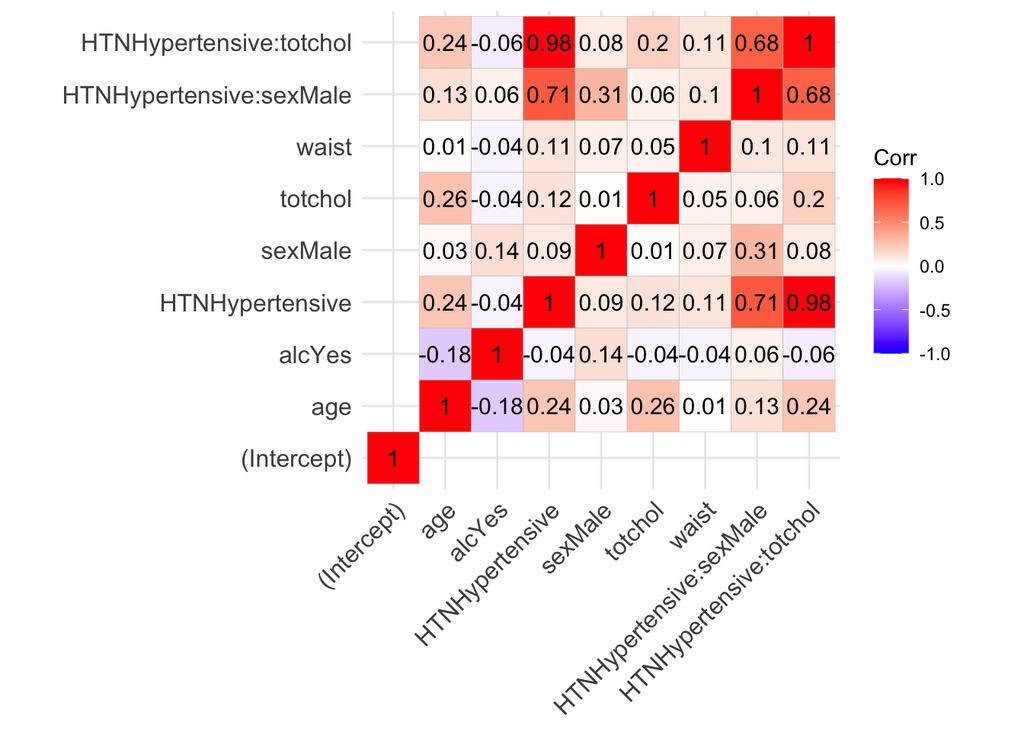

```r
model.matrix(model.sig) %>% cor() %>% ggcorrplot(lab=TRUE)
```

### 6b: Determine any predictors suspected of multicollinearity

Based on the results of the correlation matrix above, we can see that ‘HTN’ and both of the interaction terms are highly correlated with each other, where ‘HTN’ and its interaction with total cholesterol has a correlation of 0.98, ‘HTN’ and its interaction with sex has a correlation of 0.71, and the two interaction terms have a correlation of 0.68 with each other.

However, the correlation between these predictors makes sense since each of them carry information about hypertension status. Because both interaction terms are statistically significant, we determine that it is better to keep the interaction terms in the model (even if multicollinearity exists) than to remove them in favor of reducing multicollinearity. Therefore, we will remove both interaction terms before formally checking for multicollinearity.

### 6c: Formally check for multicollinearity

We utilize the variance inflation factor VIF( ) function to formally check for multicollinearity in our model. We use the rule of thumb that a VIF above 4 requires further investigation and a VIF above 10 indicates significant multicollinearity.

```r
VIF(model)
```

```
##      age      alc      HTN      sex  totchol    waist
## 1.164109 1.061461 1.080981 1.034614 1.079991 1.020888
```

Given the results we find that, after we have removed the interaction terms from the model, there is no presence of significant multicollinearity in the dataset. Each of the VIFs are well below the rule of thumb thresholds of 4 and 10.

## Problem 7:

### 7a: Graphically assess the assumptions using the almost_sas() function

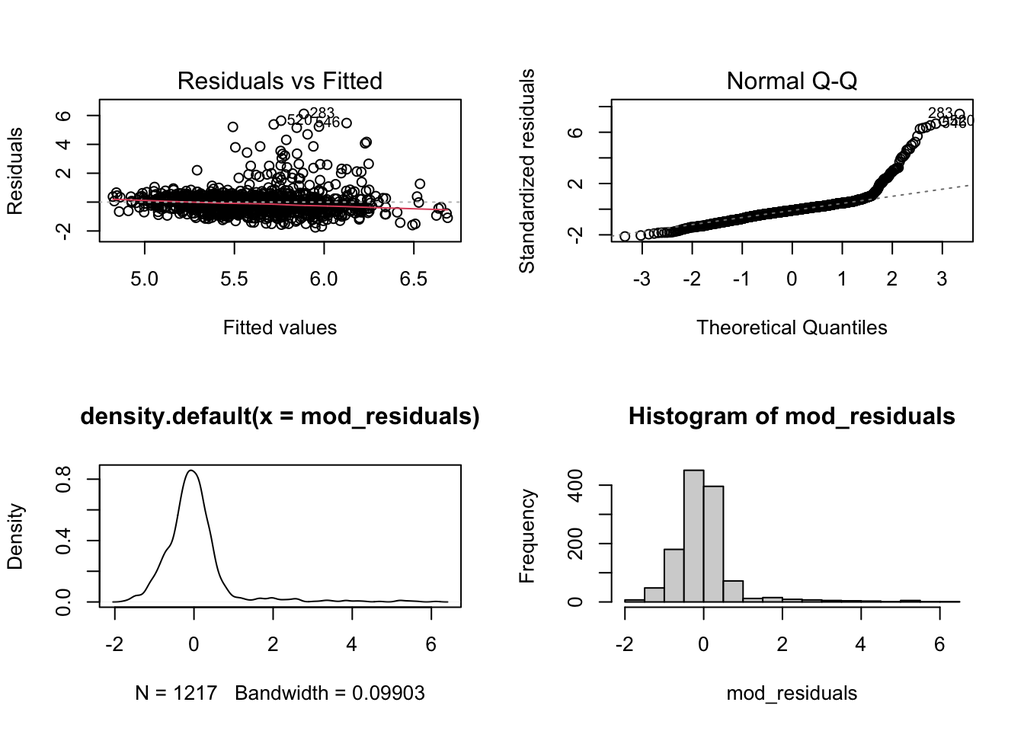

```r
almost_sas <- function(mod){
  par(mfrow = c(2,2))
  plot(mod, which = 1)
  plot(mod, which = 2)
  mod_residuals <- residuals(mod)
  plot(density(mod_residuals))
  hist(mod_residuals)
}
almost_sas(model.sig)
```

### 7c: Perform the lack of fit test

```r
model.test <- lm(HbA1c ~ 0 + age + alc + HTN + sex + totchol + waist + sex:HTN + totchol:HTN, data = df)
anova(model.sig, model.test)
```

```
## Analysis of Variance Table
##
## Model 1: HbA1c ~ age + alc + HTN + sex + totchol + waist + sex:HTN + totchol:HTN
## Model 2: HbA1c ~ 0 + age + alc + HTN + sex + totchol + waist + sex:HTN +
##     totchol:HTN
##   Res.Df    RSS Df   Sum of Sq F Pr(>F)
## 1   1208 822.68
## 2   1208 822.68  0 -2.2737e-13
```